# Global explainations

Agata Kaczmarek, Agata Makarewicz, Jacek Wiśniewski

13 05 2021

### Data preprocessing

Before performing any explainations of our model’s predictions, we needed to conduct simple data preprocessing. Based on EDA, following steps were executed:

- *handling missing values:* We identified two features containing missing values, both related to camera parameters (`back_camera_mpix`, `front_camera_mpix`). Those values turned out to be meaningful, as they simply means that given mobile phone has no camera (back or front). Given that information, NA’s were imputed with constant value - 0.
- *removing outliers:* Based on features distribution, we identified some extreme values in some of them (`back_camera_mpix`, `front_camera_mpix`, `battery_mAh`, `flash_gb`), which would weaken our model’s performance.
- *dealing with unimportant and correlated features:* We decided to omit `name` variable, because it was practically unique in our dataset and naturally connected to `brand` feature. Moreover, `height_px` and `width_px` were deleted due to their strong correlation with `diag` feature (and with each other); this feature was considered as sufficient determinant of phone’s dimensions.
- *target encoding* We encoded the only categorical variable left in our data with mean target values for each category (brand), so that we could work only with numerical features, which are easier to process.

### Model

```r
model <- ranger(price~., data = phones, num.trees = 50)
```

### Global explainations

In the second step of our XAI we focused on dataset level explainations - analysis of all predictions together and how each feature affect their average value. We used Feature Importance, Partial Dependence Profile and Accumulated Local Effect to show dependencies and draw conclusions. The advantage of those methods, in comparison to local profiles, is the fact that those explainations are true in general for our data; whereas for each observation results can differ greatly. Additionaly, we checked popular regression metrics values for our model in order to evaluate its performance.

### Metrics

We decided to assess our model’s performance with 4 common regression metrics:

- Mean Squared Error
- Root Mean Squared Error
- R2 score
- Mean Absolute Error

| mse | rmse | r2 | mae |
| --- | --- | --- | --- |
| 94071.12 | 306.7102 | 0.9532602 | 100.3325 |

Given the values of the metrics above, we can conclude that our model performs well - R2 score above 0.95 and RMSE around 300 are satisfying.

### Feature importance

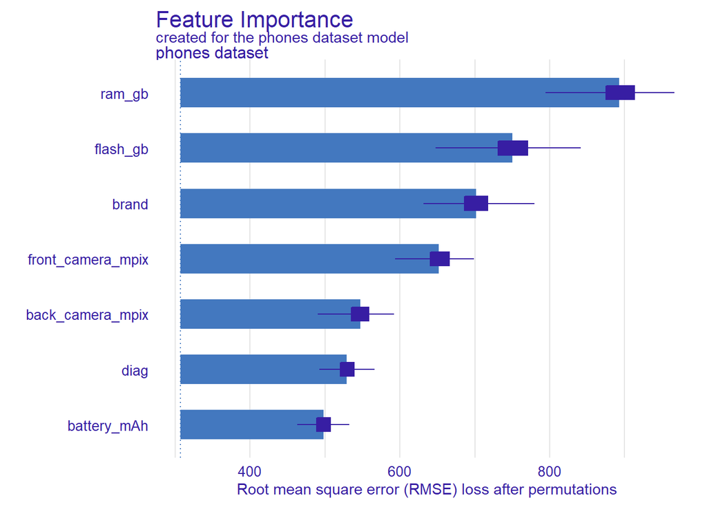

### Partial Dependence Profile

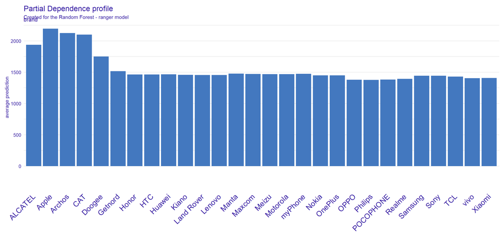

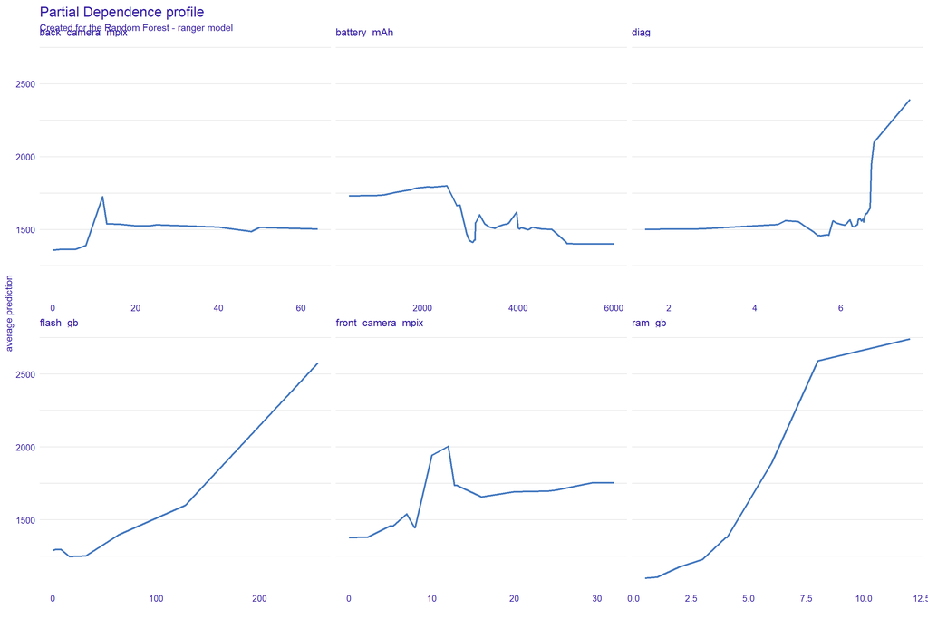